# Probabilistic A/B Testing with Stan

Imad Ali

10/30/2019

## Abstract

Statisticians, Data Scientists, etc. should not make business decisions; they should facilitate them. This case study shows how basic A/B testing using Stan and Bayesian methods can achieve this. In practice, we find this approach useful given its ability to quantify domain-specific business knowledge and hypotheses through the use of prior distributions. Instead of using p-values and confidence intervals, we are able to perform inference with probability and credible intervals directly on posterior predictions. In addition to our results being highly interpretable, this approach gives us the ability to quantify business risk. The code associated with this case study is available on GitHub: https://github.com/imadmali/ab-testing.

## Introduction

For those of you that don’t know, A/B testing is simply a randomized controlled trial applied in a business context. The test is conducted on a subset of users in order to determine if a change in service (e.g. user experience) will have a positive impact on the business before rolling out that change to all the users.

Below we provide some stylized scenarios where A/B testing could provide useful insight.

- If you change the theme of your site will users stay on the site for longer?
- If you add a new set of emoji reactions will users use them?
- Is there a noticable difference between the three point accuracy of two basketball players?
- In a drug trial, is ther evidence that the treatment works over the placebo?

Typically, A/B testing involves one group of people being served the existing content (control group) while another group is served different content (treatment group) and, through a measurable indicator, the business wants to determine if there is a difference in reaction between the two groups. If we compare the two groups and find that the difference in the indicator is substantially large then we can argue that the different content drove that change. Conversely, if the change was minimal then you may be hesitant to conclude that the different content resulted in any change in behavior at all. In that situation perhaps the content needs to be redesigned (and retested).

Most A/B testing approaches used in practice typically rely on Frequentist hypothesis testing methods. Not only are the results of these methods difficult to interpret, but they can also be misleading. Terms such as “p-values” and “confidence intervals” are often misinterpreted as probabilities directly related to the parameter of interest (e.g. difference in means between two groups). Disconcertingly, p-values are often used as cutoffs for a business decision. In other words, reaching a statistically signficant result is often sufficient to convince a business to move forward with a particular decision.

We argue that these descisions should not be reductively derived from arbitrary cutoffs (e.g. a p-value of less than 0.05). Instead they should be determined by domain-specific experts who understand the industry, with statisticians providing interpretable results that can help these experts make more informed decisions. This case study provides a way for domain-specific experts to apply their knowledge to the statistical inference process of A/B testing through prior distributions. Additionally, the experts can quantify the risk they’re willing to take and probabilistically incorporate this into the inference.

Some key benefits to the Bayesian approach outlined in this case study include,

- Allowing domain-specific experts to apply their knowledge and appetite for risk to statistical inference.
- Modeling the data rather than defining/computing a test statistic from the data. (This allows us to perform inference on the (predicted) data instead of the parameters.)
- The ability to describe differences in groups probabilistically rather than using traditional hypothesis testing methods.
- Quantifying null hypotheses in priors.

We use simple examples to show how to apply Bayesian inference to A/B testing using continuous and count data. The examples used here are analogous to the t-test and the Fisher’s exact test, but the methodology discussed can be applied to data that follow other distributions. The first section considers continuous data (assumed to be generated from the normal distribution) and the second section considers count data (assumed to be generated from the binomial distribution). (If you need a referesher on how convoluted hypothesis testing is, Appendix A goes over the interpretation of p-values using a two-sample t-test as an example.)

At a high-level, we stress that Frequentist methods focus on the distribution of the test statsitic as opposed to the quantity of interest (i.e. predictions or parameters). In such methods inference is done by understanding how the observed test statistic compares to the distribution of the test statistic under the null hypothesis. Alternatively, the Bayesian approach proposed here allows the statistician to perform inference directly on the quantity of interest (in this case predicted data), which is more transparent and informative in the context of A/B testing.

## Continuous Data

*This example is analogous to the two sample t-test (specifically Welch’s t-test) where the statistician is interested in testing if there is a noticeable difference between the means of two different samples.*

Suppose an online streaming company is interested in testing whether ads affect the consumption of their service. The hypothesis is that reducing ads will increase hourly streaming consumption. Since this decision can be costly if a significant amount of revenue is derived from ads, it would be useful to conduct a test to evaluate the impact of ad reduction. One way to test this is to draw two random samples from the user base, serve them with different content, and see if there is a substantial difference in streaming consumption (hours per day). Suppose we treat the two groups in the following way,

- Group A (control): streaming service contains moderate ads.
- Group B (treatment): streaming service contains no ads.

The data collected might look something like the following below. Each observation is a user’s daily streaming consumption in hours.

```r
# rnorm(12,3,1)
group_a <- c(3.432119, 3.727513, 2.288977, 2.284448, 2.573595, 3.078873,
             3.307105, 2.445558, 2.557591, 2.950913, 3.083117, 2.922103)
# rnorm(10,6,1)
group_b <- c(6.210725, 5.31649, 5.298087, 5.539633, 4.561971,
             5.001099, 3.382349, 5.2544, 4.484435, 3.837214)
```

In order to determine if there is a difference between the groups we first need to model the data for each group. In this situation we only have a single variable in each group (the outcome variable). It is reasonable to assume that the outcome is generated from the normal distribution. Given this, we want the likelihood distribution of the model to be the normal distribution. Since we have no predictors the model will estimate a location and a scale parameter for each group.

We can apply prior distributions on each of these parameters. This is where the domain-specific expert can provide valuable input. For example, they may believe that (due to poor sampling) the sampled average of daily streaming hours is too low. In such a situation a prior can be applied to coerce the estimated average closer to the value they feel is more appropriate and representative of the population.

$$\begin{align*}
y_{A} \sim &\mathcal{N}(\mu_{A}, \sigma_{A}) \\
&\mbox{priors on } \mu_{A}, \sigma_{A} \\
y_{B} \sim &\mathcal{N}(\mu_{B}, \sigma_{B}) \\
&\mbox{priors on } \mu_{B}, \sigma_{B} \\
\end{align*}$$

Now that we have established our model, we need to fit the model to the data so that we can estimate the parameters. We can do this using the [**rstanarm**](https://mc-stan.org/rstanarm/) package which can fit a Bayesian linear regression model (using the `stan_glm()` function) to each group with only the intercept as a predictor. With this model construction, the intercept is interpreted as the location parameter.

With regard to priors, we have applied $\mathcal{N}(3,1)$ distributions on both intercepts. The reasoning behind this is that the empirical mean of the control group is approximately $3$. By applying this prior to the treatment group we are quantifying our belief that the treatment group is not substantially different to the control group, which is our null hypothesis. (This is a reasonable belief to have since the whole purpose of the experiment is to evaluate whether the two groups are actually different.) This can be interpreted as incorporating the belief underlying our null hypothesis into the prior. This approach allows us to be more conservative when we do our inference. If we end up concluding that the two groups are different, we can say that the difference in behavior was so strong that it overcame our prior belief that the two groups are identical.

Below we fit the model.

```r
fit_group_a <- stan_glm(y ~ 1,
                        data = data.frame(y=group_a),
                        family = gaussian(link="identity"),
                        prior_intercept = normal(3, 1, autoscale = FALSE), seed = 123)
fit_group_b <- stan_glm(y ~ 1,
                        data = data.frame(y=group_b),
                        family = gaussian(link="identity"),
                        prior_intercept = normal(3, 1, autoscale = FALSE), seed = 123)
```

Recall that Stan uses a sampling algorithm to estimate the marginal posterior distribution of the parameters which means that we have samples instead of point estimates for the intercept values. For Group A the mean of the intercept samples is,

```r
coef(fit_group_a)
## (Intercept)
##    2.889382
```

For Group B the mean of the intercept samples is,

```r
coef(fit_group_b)
## (Intercept)
##    4.879374
```

With these estimates it looks like Group A had an average consumption of about 3 hours while Group B had an average consumption of about 5 hours. This gives us a difference in consumption of approximately 2 hours. Unfortunately, this assessement does not say anything about how uncertain this difference is. We would like to be able to say something like “we are $p\%$ sure that the two groups are different”.

We can quantify the uncertainty of how different the two estimates are by computing sample quantiles on the posterior predictive distribution. This is known as a credible interval. It is also refered to as the highest density interval (Kruschke 2015). If we compute the $90\%$ credible interval then we can say that $90\%$ of the posterior predictions for that group lie between that interval. In order for us to determine how different these groups are we can compute how much of the credible intervals in each of the two groups overlap as a proportion. For example, suppose there is a $10\%$ overlap between the $90\%$ credible intervals in each of the two groups. This allows us to say, given that we are $90\%$ certain about where the predictions lie, there’s a $10\%$ chance that the two groups are similar.

The functions below compute the proportion of overlap between the two groups.

```r
#' Quantify Overlapping Proportion
#' Compute how much of the smaller distribution overlaps with the larger (i.e. wider) distribution.
#' @param large Posterior predictive samples that have larger range than \code{small}.
#' @param small Posterior predictive samples that have smaller range than \code{large}.
#' @param p Probability to compute credible interval.
#' @return A proportion between 0 and 1 indicating how much of \code{small} is contained in \code{large} given the credible interval specification.
overlap_prop <- function(large, small, p = 1) {
  p_lwr <- (1-p)/2
  p_upr <- 1 - p_lwr
  large_ci <- quantile(large, probs = c(p_lwr, p_upr))
  left <- min(large_ci)
  right <- max(large_ci)
  indxs <- which(small >= left & small <= right)
  return(length(indxs)/length(small))
}

#' Quantify Overlapping Posterior Predictive Distributions
#' Quantify the overlap between posterior samples from two distributions.
#' @param a Group A posterior predictive samples.
#' @param b Group B posterior predictive samples.
#' @param p Probability to compute credible interval.
#' @return A proportion between 0 and 1 indicating how much of the credible intervals for \code{a} and \code{b} overlap with one another.
overlap <- function(a, b, p = 1) {
  length_a <- dist(range(a))
  length_b <- dist(range(b))
  if (length_a >= length_b) {
    out <- overlap_prop(a, b, p)
  }
  else if (length_a < length_b) {
    out <- overlap_prop(b, a, p)
  }
  return(out)
}
```

Below we compute the $0.9$ credible interval for both groups. Note that the credible interval choice is arbitrary, and may vary depending on the applied context and the appetite for uncertainty. This is also where we recommend getting input from domain-specific experts. In this case we are willing to accept a $10\%$ chance of being wrong about where the predictions lie. The closer the credible interval is to $1$ the more risk averse the business is with regards to inference.

```r
pp_a <- posterior_predict(fit_group_a)
pp_b <- posterior_predict(fit_group_b)
pp_a_quant <- quantile(pp_a, probs = c(0.05,0.95))
pp_b_quant <- quantile(pp_b, probs = c(0.05,0.95))

overlap(pp_a, pp_b, p = 0.9)
```

```
## [1] 0.2041667
```

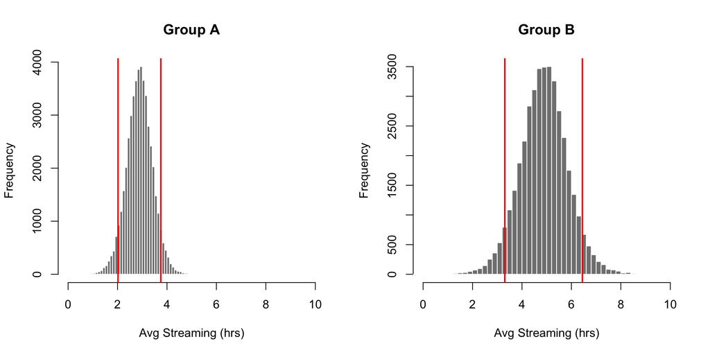

```r
par(mfrow=c(1,2))
# group A
hist(pp_a, breaks = 50, col = '#808080', border = '#FFFFFF',
     main = "Group A",
     xlab = "Avg Streaming (hrs)",
     xlim = c(0,10))
abline(v = pp_a_quant[1], lwd = 2, col = "red")
abline(v = pp_a_quant[2], lwd = 2, col = "red")
# group B
hist(pp_b, breaks = 50, col = '#808080', border = '#FFFFFF',
     main = "Group B",
     xlab = "Avg Streaming (hrs)",
     xlim = c(0,10))
abline(v = pp_b_quant[1], lwd = 2, col = "red")
abline(v = pp_b_quant[2], lwd = 2, col = "red")
```

After computing the $90\%$ credible interval for both groups we find an overlap proportion of approximately $0.2$. Thus, given that we are $90\%$ sure about our posterior predictions for the two groups, we are about $80\%$ sure that the two groups are in fact different. Going back to the business context, we can conclude that we are $80\%$ sure that reducing ads increases daily streaming consumption given our acceptable risk of being $10\%$ wrong about daily streaming consumption.

In the plot below we show how the overlap proportion will vary as the credible interval varies. To put it differently, it shows how the probabilistic difference between groups varies as risk varies. Notice that the more risk we take when defining our credible interval (i.e. the closer the credible interval is to 0) the lower the overlap proportion, and consequentially the more confident we are about the difference between the two groups.

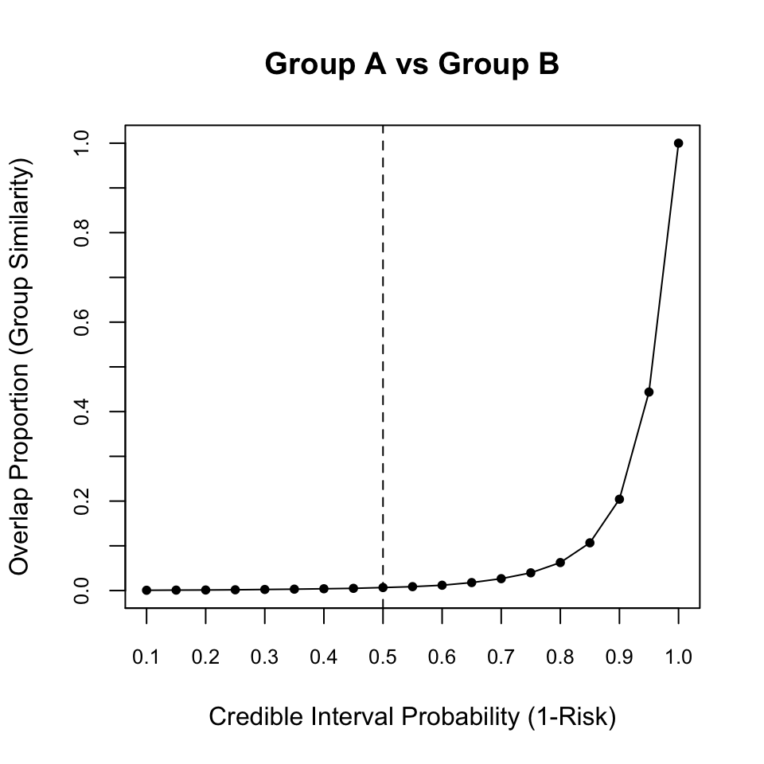

```r
# credible interval probabilities
ci_p <- rev(seq(0.1,1, by = 0.05))
# compute proportions
overlap_ab <- sapply(ci_p, function(s){overlap(pp_a, pp_b, s)})
# plot
plot(ci_p, overlap_ab, type = "o", pch = 20,
     xaxt = "n", yaxt = "n",
     main = "Group A vs Group B", xlab = "Credible Interval Probability (1-Risk)", ylab = "Overlap Proportion (Group Similarity)")
axis(1, seq(0,1,by=0.1), cex.axis = 0.8)
axis(2, seq(0,1,by=0.1), cex.axis = 0.8)
abline(v = 0.5, lty = 2)
```

## Count Data

*This example is analogous to Fisher’s exact test where the statistician is interested in testing differences in proportions (particularly in the form of a contingency table).*

Now, suppose that the business wants to know whether a product sells better if there is a change to the online user interface (UI) that consumers interact with to buy the product. They run an experiment on two groups and obtain the following results,

- Group C (control): 10 customers out of a sample of 19 purchased the product with the default UI.
- Group D (treatment): 14 customers out of a sample of 22 purchased the product with the alternative UI.

It is resonable to assume that the data is binomially distributed, in which case we can define the model for the the two groups as follows,

$$\begin{align*}
y_{C} \sim &\mbox{Bin}(\theta_{C},N_{C}) \\
&\mbox{priors on } \theta_{C} \\
y_{D} \sim &\mbox{Bin}(\theta_{D},N_{D}) \\
&\mbox{priors on } \theta_{D} \\
\end{align*}$$

We can fit a model to each group independently using the [**rstan**](https://mc-stan.org/rstan/) package. This requires us to specify the model in a Stan file and then compile/fit the model with the `stan()` function. The Stan file used to represent the above model is provided below. We decided to apply a beta distribution prior on the probability parameter of the binomial distribution.

```stan
data {
  int<lower=0> N;
  int y[N];
  int trials[N];
  real<lower=0> shape1;
  real<lower=0> shape2;
}
parameters {
  real theta;
}
model {
  target+= binomial_lpmf(y | trials, theta);
  target+= beta_lpdf(theta | shape1, shape2);
}
generated quantities {
  int y_hat[N];
  for (n in 1:N)
    y_hat[n] = binomial_rng(trials[n], theta);
}
```

Below we fit this model to the data. In this case we chose the hyperparameters in the beta distribution in such a way that the prior distribution mimics the uniform distribution over support $[0,1]$.

```r
group_c <- list(N = 1,
                y = as.array(10),
                trials = as.array(19),
                shape1 = 1,
                shape2 = 1)
group_d <- list(N = 1,
                y = as.array(14),
                trials = as.array(22),
                shape1 = 1,
                shape2 = 1)
fit_group_c <- stan("../models/binom.stan", data = group_c,
                    chains = 4, iter = 1e3, control = list(adapt_delta = 0.95),
                    seed = 123)
fit_group_d <- stan("../models/binom.stan", data = group_d,
                    chains = 4, iter = 1e3, control = list(adapt_delta = 0.95),
                    seed = 123)
```

Similar to the method described in the previous section we compute and plot the $90\%$ credible intervals for the posterior predictions in each group. We also compute the overlap proportion of these two sets of predictions.

```r
samples_group_c <- as.matrix(fit_group_c)
samples_group_d <- as.matrix(fit_group_d)
pp_c <- samples_group_c[,"y_hat[1]"]
pp_d <- samples_group_d[,"y_hat[1]"]
pp_c_quant <- quantile(pp_c, probs = c(0.05,0.95))
pp_d_quant <- quantile(pp_d, probs = c(0.05,0.95))

# compute overlap
overlap(pp_c, pp_d, p = 0.9)
```

```
## [1] 0.6805
```

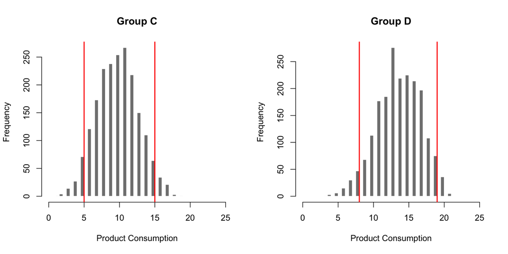

```r
# plot
# group C
par(mfrow=c(1,2))
hist(pp_c, breaks = 50, col = '#808080', border = '#FFFFFF',
     main = "Group C",
     xlab = "Product Consumption",
     xlim = c(0,25))
abline(v = pp_c_quant[1], lwd = 2, col = "red")
abline(v = pp_c_quant[2], lwd = 2, col = "red")
# group D
hist(pp_d, breaks = 50, col = '#808080', border = '#FFFFFF',
     main = "Group D",
     xlab = "Product Consumption",
     xlim = c(0,25))
abline(v = pp_d_quant[1], lwd = 2, col = "red")
abline(v = pp_d_quant[2], lwd = 2, col = "red")
```

Looking at the histograms it’s clear that there’s quite a bit of overlap between the two groups. The overlap proportion is about 0.7. So under our $90\%$ credible interval, there is a $70\%$ chance that there is no difference in behavior when the UI changes. This suggests that we don’t have strong evidence that the UI change encouraged change in behavior.

Below we show how the overlap proportion varies based on the amount of risk we’re willing to take when we define our credible intervals. Similar to the continuous example, risk is inversely related to group similarity.

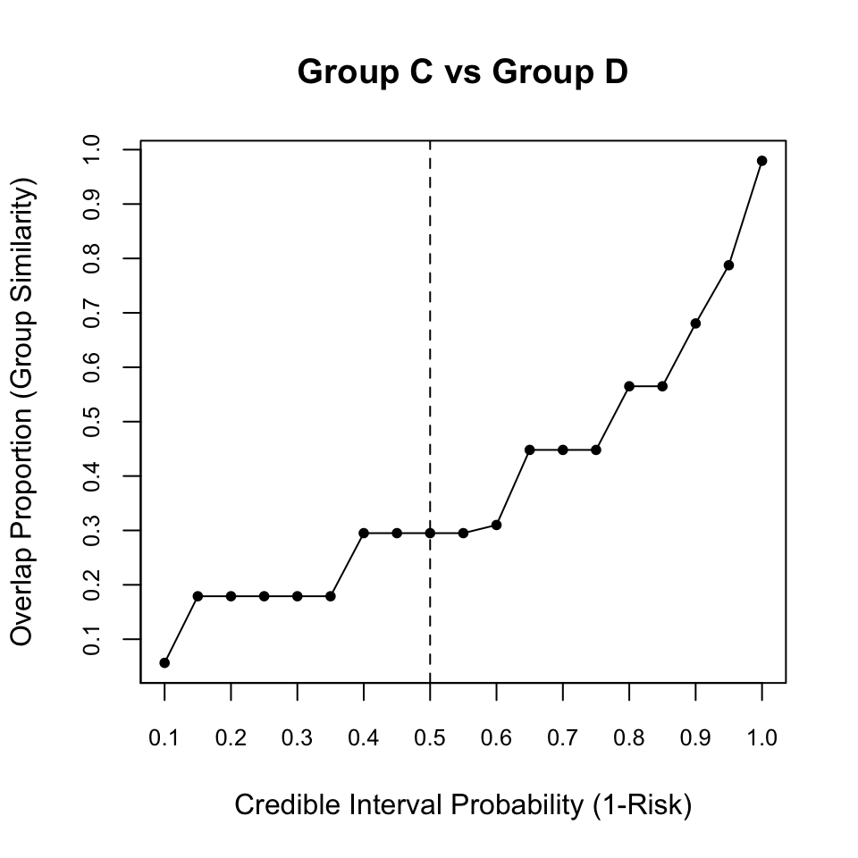

```r
# credible interval probabilities
ci_p <- rev(seq(0.1,1, by = 0.05))
# compute proportions
overlap_cd <- sapply(ci_p, function(s){overlap(pp_c, pp_d, s)})
# plot
plot(ci_p, overlap_cd, type = "o", pch = 20,
     xaxt = "n", yaxt = "n",
     main = "Group C vs Group D", xlab = "Credible Interval Probability (1-Risk)", ylab = "Overlap Proportion (Group Similarity)")
axis(1, seq(0,1,by=0.1), cex.axis = 0.8)
axis(2, seq(0,1,by=0.1), cex.axis = 0.8)
abline(v = 0.5, lty = 2)
```

Note, this example involved a really small data set (only one observation for each group). But the same model can easily be extended to many observations within each group. Also, just as we described in the continuous example, we can define a more comprehensive model for the outcome if we had predictors.

## Benefits of Bayesian Methods

The key benefits that we have discussed include the ability to probabilistically interpret the results of our inference, and the ability to incorporate prior beliefs (i.e. business knowledge and hypotheses) into our models.

**Interpretation of probability**

With regards to interpretation, there are some of the advantages of taking a Bayesian inference approach to A/B testing using Stan:

1. The ability to communicate our results using the intuitive concept of probability.
2. The ability to quantify business knowledge in priors.
3. The ability to quantify business risk using probability when doing inference.

Quantifying our uncertainty probabilistically enables us to make statments like ‘based on the data collected, the model specified, and the risk we’re willing to take; we are 80% certain that the two groups are different.’ This is much more interpretable than statements like ‘with a p-value of less than 0.2 we can reject the null hypothesis that the two groups are identical’. While this is not exclusively a Bayesian benefit (i.e. we could have completely excluded priors from our models, estimating the parameters solely from the likelihood of the data), we took advantage of the fact that appropriately implemented Bayesian computational methods rely on robust sampling methods. These samples can then be transformed and used to make probabilistic statements about posterior predicitive distribution, and consequentially about the hypothesis being tested.

**Incorporating prior beliefs**

The ability to define a prior distribution on your parameters is a key benefit of Bayesian methods. Prior information can be incorporated in your model with two choices: the type of the distribution and how the distribution is parametrized.

The type of distribution relates to which distribution you choose to define on the parameters. In the continuous data example we chose the normal distribution. But, since the underlying data (hours streamed per day) cannot be negative, it might be more sensible to define a truncated normal distribution as the prior (which is straightforward to implement in rstan). This gives us the opportunity to model the data generation process more appropriately.

How the prior distribution is parameterized reflects your belief on the value that parameter takes. In the continuous data example we showed how we parametrized the prior distribution for the treatement group to capture our prior belief that the two groups are similar. A similar approach can be taken for the treatment group in the count data example.

With these types of priors, if we concluded that the two groups are in fact different then we could really be sure that the treatment actually changed the treatment group’s behavior. In other words, the treatment group’s observed behavior overcame our prior belief. We could also tune this belief to be more or less strong by adjusting where most of the density/mass of the prior distribution sits. Applying this type of prior would help mitigate false-positive conclusions from this type of analysis.

## Conclusion

Below is an abstracted summary of the inference process we’ve gone through to compare groups involved in A/B testing.

1. Model the indicator that is being measured to track the difference between the two groups.
2. Compute the credible interval $c$ over the posterior predictions of the two groups. $1-c$ quantifies how much risk the business is willing to take in regards to the predicted indicator. The value of $c$ should be driven by domain-specific experts.
3. Compute the proportion $p$ of how much each interval overlaps with one another. $p$ defines the similarity between the two groups.

After implementing the steps above, we can construct the following conclusion: given there is a $(1-c)100$ percent chance that we are wrong about the predictions, there is a $(1-p)100$ percent chance that the two groups are different.

The Bayesian methods outlined in this case study focused on modeling the data generation process and performing inference on the posterior predictive distribution of two groups. We did not need to worry about computing test statistics and determining the distribution of these statistics under the null hypothesis. Nor did we need to calculate p-values to figure out whether the groups involved in A/B testing are different. Instead we performed inference directly on the posterior predictions. By constructing credible intervals and computing the overlap of these intervals we are able to probabilistically convey how sure we are about the difference between the two groups. Bayesian inference gives statisticians the ability to quantify business information/risk and enables them to communicate uncertainty unambiguously to decision makers, allowing more informed decisions to be made.

## Acknowlegements

Thanks to Jonah Gabry and Charles Zhou for feedback on initial drafts.

## References

Fisher’s exact test. Wikipedia. Available from https://en.wikipedia.org/wiki/Fisher%27s_exact_test.

Gallo, A. (2017) A Refresher on A/B Testing. *Harvard Business Review*. https://hbr.org/2017/06/a-refresher-on-ab-testing.

Goodrich, B., Gabry, J., Ali, I. & Brilleman, S. (2019). rstanarm: Bayesian applied regression modeling via Stan. R package version 2.17.4. http://mc-stan.org/.

Krushke, J.K. (2015). *Doing Bayesian Data Analysis - A Tutorial with R, JAGS, and Stan*. Elsevier, New York, 2nd edition.

Stan Development Team (2019). RStan: the R interface to Stan. R package version 2.19.2. http://mc-stan.org/.

Student’s t-test. Wikipedia. Available from https://en.wikipedia.org/wiki/Student's_t-test.

Welch’s t-test. Wikipedia. Available from https://en.wikipedia.org/wiki/Welch%27s_t-test.

## Appendix A: Refresher on p-values

Recall that Frequentist methods of hypothesis testing involve constructing a test statistic with the available data. Then, using the distribution of that test statistic under the null hypothesis, you can determine the probability of observing statistics that are more extreme than the one calculated. This is known as a p-value. A small p-value suggests a small probability of observing a more extreme test statistic, which in turn means that it is unlikely for that statistic to have been generated under the null hypothesis. Since the statistic is computed from the data this suggests that the data itself is unlikely to have been generated under the null hypothesis. The value of how small is a small p-value is up to the statistican.

As an example consider the data associated with Group A and Group B in the continuous data section. The null hypothesis is whether the two groups have equal means. Below we compute the test statistic and p-value given the data.

```r
t_test <- t.test(x=group_a, y=group_b)
t_stat <- abs(t_test$statistic)
p_value <- t_test$p.value
print(p_value)
```

```
## [1] 1.146692e-05
```

```r
# you can manually compute the p-value with the following code
# p_value <- pt(-t_stat, t_test$parameter)*2

# you can manually compute the confidence intervals with the following code
# group_a_mean <- mean(group_a)
# group_b_mean <- mean(group_b)
# v <- sqrt((var(group_a)/length(group_a)) + (var(group_b)/length(group_b)))
# ci_lwr <- (group_a_mean - group_b_new_mean) - abs(qt(0.025, t_test$parameter[['df']])*v)
# ci_upr <- (group_a_mean - group_b_new_mean) + abs(qt(0.025, t_test$parameter[['df']])*v)
```

The p-value in this case is really small, approximately zero. We can visualize this result. Since we know that the test statistic is t-distributed we can plot what the distribution of the test statistic under the null, along with the test statistic calculated with the observed data. This is illustrated below. The red lines are the (two-tailed) test statistics calculated from the data.

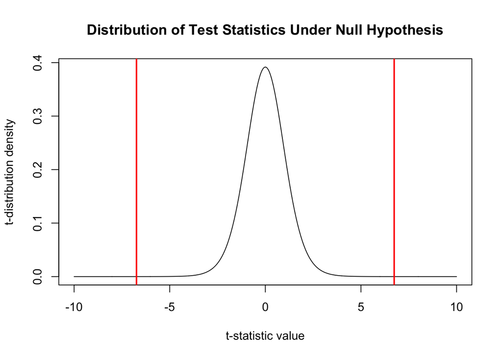

```r
dof <- t_test$parameter[["df"]]
x <- seq(-10,10,length.out = 1e3)
plot(x, dt(x, dof), type = "l",
     main = "Distribution of Test Statistics Under Null Hypothesis",
     xlab = "t-statistic value",
     ylab = "t-distribution density")
abline(v=-t_stat, col="red", lwd=2)
abline(v=t_stat, col="red", lwd=2)
```

Given the small p-value we can make the following sequence of conclusions:

1. The computed test statistic is unlikely to occur under the null.
2. The data (used to compute this statistic) is unlikely to have been generated under the null.
3. Therefore the null must be invalid and can be rejected, allowing us to conclude that the two groups are different.

Notice how far removed we are from the data and the observed data generation process. Once we calculate the test statistic we step away from the distribution of the data itself and start dealing with the distribution of the test statistic under the null. We were also unable to encode any prior belief or business knowledge into our inference.